# History of Phylosophy: More Focused and Less Neutral as Evolving

## 2 Analysis of the Schools

### 2.1 Wordcould Analysis

In the cell below, we create a wordcloud image for each school.

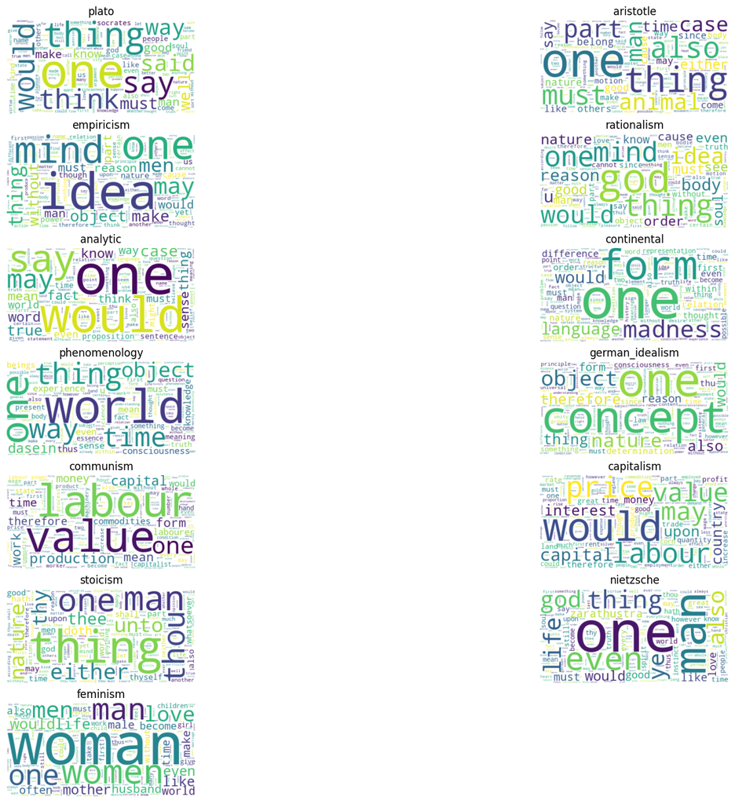

```python
school = df['school'].unique().tolist()
stop_words = set(stopwords.words('english'))
plt.figure(figsize=(20,16)) #set figure size
for s in range(len(school)):
    df_temp = df[df.school==school[s]]
    text = " ".join(txt for txt in df_temp.sentence_lowered)
    plt.subplot(7,2,s+1).set_title(school[s])
    wordcloud = WordCloud(stopwords=stop_words,background_color="white").generate(text)
    plt.imshow(wordcloud, interpolation="bilinear")
    plt.axis("off")
plt.show()
```

It is obvious that the phylosophy in the early stage tend to focus more on human self, and they have a lot of high frequency words where people hardly grasp the key idea from the world cloud. They tend to use words such as one, thing, and say. Some other words with high frequencies are relatively less related to the core topic of the specific school. However, as time involves, philosophy are more related to other realms when sociology and economics developed rapidly. Each school is more focused on one specific problem instead of being general. Examples of this trend are capitalism, communism, and feminism. One of the characteristics observed from the plots above is that the number of high frequency word is fewer than early schools. Also, it is easier to identify these schools from others as they have a clear focus such as labour, capital value, or women rights.

### 2.2 Sentiment Analysis

The cell below generate a barchart of sentiment for each school.

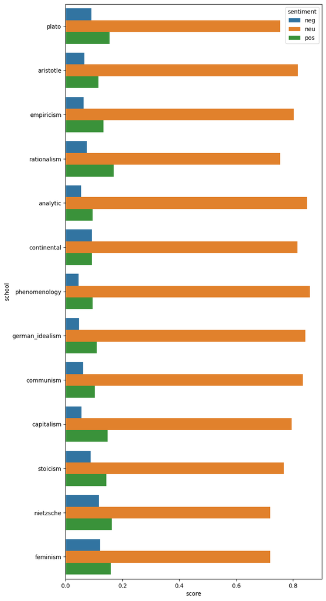

```python
school_score = []
school1 = []
senti = []
senti1= ['neg','neu','pos']
for s in range(len(school)):
    df_temp = df[df.school==school[s]]
    text_list = df_temp.lemmatized_str.to_list()
    list1 = sample(text_list,min(1000,len(text_list)))
    text = ' '.join(list1) #text of the school
    sia = SentimentIntensityAnalyzer()
    score = sia.polarity_scores(text)
    for i in range(len(senti1)):
        school1.append(school[s])
        school_score.append(score.get(senti1[i]))
    senti.extend(senti1)
school_df = pd.DataFrame(zip(school1,school_score,senti),columns=['school','score','sentiment'])
plt.figure(figsize=(8,18))
sns.barplot(x='score',y='school',hue='sentiment', data=school_df) # generate barplot for each school
plt.show()
```

## 3. Analysis on Authors

### 3.1 Word Could Analysis

After examine the schools, we may see the authors and see if similar trends continues to exist. The following cell demonstrate the wordcloud for each author.

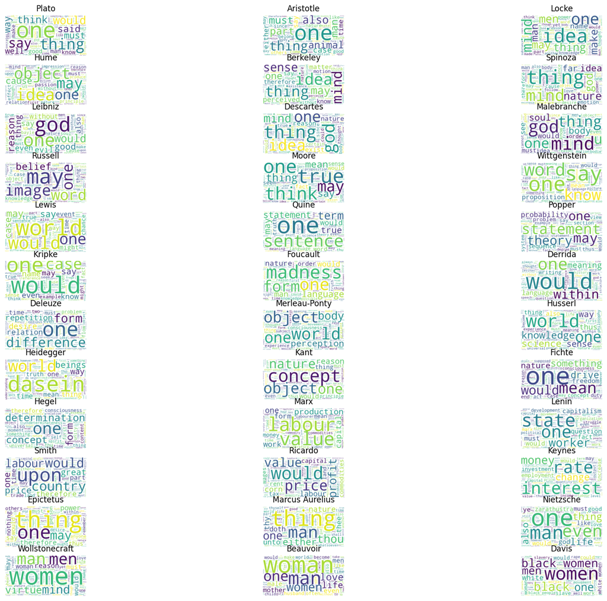

```python
author = df['author'].unique().tolist()
stop_words = set(stopwords.words('english'))
plt.figure(figsize=(20,16))
for a in range(len(author)):
    df_temp = df[df.author==author[a]]
    text = " ".join(txt for txt in df_temp.sentence_lowered)
    plt.subplot(12,3,a+1).set_title(author[a])
    wordcloud = WordCloud(stopwords=stop_words,background_color="white").generate(text)
    plt.imshow(wordcloud, interpolation="bilinear")
    plt.axis("off")
plt.show()
```

From the word cloud above, the trend follows as discribed in 2.1. Early philosopher tend to have more general topic with less focus. They are more likely to discuss human-being and mindset instead of exterior topics. As time involves, philosopher are getting more focused on a smmall topic such as human-being, human rights, or economics. In this stage, people such as Marx and Wollstonecraft are getting a clear focus on specific word as shown on the word cloud which is also the key of corresponding school.

### 3.2 Sentiment Analysis

The cell below generate a barplot demontrating sentiment analysis on each author's text.

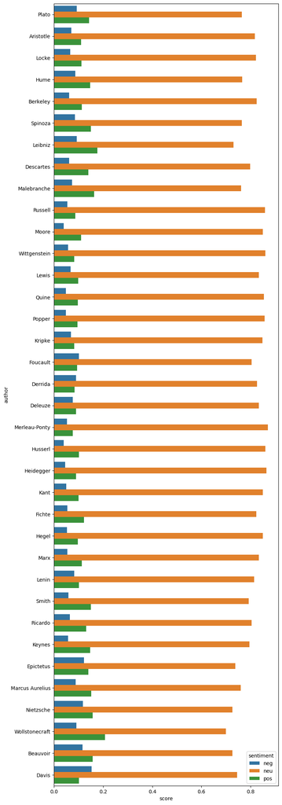

```python
author_score = []
author1 = []
senti = []
senti1 = ['neg','neu','pos']
for a in range(len(author)):
    df_temp = df[df.author==author[a]]
    text_list = df_temp.lemmatized_str.to_list()
    list1 = sample(text_list,min(1000,len(text_list)))
    text = ' '.join(list1)
    sia = SentimentIntensityAnalyzer()
    score = sia.polarity_scores(text)
    for i in range(len(senti1)):
        author1.append(author[a])
        author_score.append(score.get(senti1[i]))
    senti.extend(senti1)
author_df = pd.DataFrame(zip(author1,author_score,senti),columns=['author','score','sentiment'])
plt.figure(figsize=(8,28))
sns.barplot(x='score',y='author',hue='sentiment', data=author_df) #generate bar plot for each author
plt.show()
```